# dplyr

## Before we begin

Please download, install, and load `pnwflights14` package from the the github account of user `ismayc`.

(If you've never done this before, google around (or look at old slides) to figure out how to load a package from github)

## Two paradigms

### R

```r
cyl4s <- mtcars[mtcars$cyl == 4, ]
mean(cyl4s$mpg)
```

```
## [1] 26.66364
```

### R with dplyr

```r
library(dplyr)
cyl4s <- filter(mtcars, cyl == 4)
summarize(cyl4s, mean = mean(mpg))
```

```
##       mean
## 1 26.66364
```

## R Subsetting

```r
cyl4s <- mtcars[mtcars$cyl == 4, ]
```

- Square brackets are used to subset dataframes.
- `[rows, columns]`

## R Summaries

```r
mean(cyl4s$mpg)
```

```
## [1] 26.66364
```

- Many commands operate on a *vector* (column) of data extracted from a dataframe using the `$`.

## dplyr Subsetting

```r
cyl4s <- filter(mtcars, cyl == 4)
```

- `dplyr` contains separate functions to *filter* the rows and *select* the columns.
- The dataframe is one argument and the column names are another (no `$`).

```r
cyl4s <- mtcars %>% filter(cyl == 4)
```

- Can also *chain* commands using the pipe.

## dplyr Summaries

```r
summarize(cyl4s, mean = mean(mpg))
```

```
##       mean
## 1 26.66364
```

- Any numerical summary that you want to apply to a column of a dataframe is specified within `summarize()`.

```r
cyl4s %>% summarize(mean = mean(mpg))
```

```
##       mean
## 1 26.66364
```

- This, too, can be put into a chain.

## Two paradigms

### R

```r
cyl4s <- mtcars[mtcars$cyl == 4, ]
mean(cyl4s$mpg)
```

```
## [1] 26.66364
```

### R with dplyr

```r
library(dplyr)
cyl4s <- filter(mtcars, cyl == 4)
summarize(cyl4s, mean = mean(mpg))
```

```
##       mean
## 1 26.66364
```

## Why dplyr?

Data sets are often of high *volume* (lots of rows) and high *variety* (lots of columns). This is overwhelming to visualize and analyze, so we find ourselves chopping the data set up into more manageable and meaningful chunks. We also often need to perform operations to organize and clean our data.

This is all possible in base R, but with `dplyr`, it is **simple**, **readible**, and **fast**.

## The Seven Verbs (commands)

- filter
- arrange
- select
- distinct
- mutate
- summarize
- sample_n

## filter()

Allows you to select a subset of the **rows** of a data frame. The first argument is the name of the data frame, the following arguments are the filters that you'd like to apply.

For all flights on January 1st:

```r
library(pnwflights14)
filter(flights, month == 1, day == 1)
```

```
## # A tibble: 419 x 16
##     year month   day dep_time dep_delay arr_time arr_delay carrier tailnum
##    <int> <int> <int>    <int>     <dbl>    <int>     <dbl>   <chr>   <chr>
## 1   2014     1     1        1        96      235        70      AS  N508AS
## 2   2014     1     1        4        -6      738       -23      US  N195UW
## 3   2014     1     1        8        13      548        -4      UA  N37422
## 4   2014     1     1       28        -2      800       -23      US  N547UW
## 5   2014     1     1       34        44      325        43      AS  N762AS
## 6   2014     1     1       37        82      747        88      DL  N806DN
## 7   2014     1     1      346       227      936       219      UA  N14219
## 8   2014     1     1      526        -4     1148        15      UA  N813UA
## 9   2014     1     1      527         7      917        24      UA  N75433
## 10  2014     1     1      536         1     1334        -6      UA  N574UA
## # ... with 409 more rows, and 7 more variables: flight <int>,
## #   origin <chr>, dest <chr>, air_time <dbl>, distance <dbl>, hour <dbl>,
## #   minute <dbl>
```

## Constructing filters

Filters are constructed of **logical operators**: `<`, `>`, `<=`, `>=`, `==`, `!=` (and some others).

Adding them one by one to `filter()` is akin to saying "this AND that". To say "this OR that OR both", use |.

```r
filter(flights, month == 1 | month == 2)
```

```
## # A tibble: 23,044 x 16
##     year month   day dep_time dep_delay arr_time arr_delay carrier tailnum
##    <int> <int> <int>    <int>     <dbl>    <int>     <dbl>   <chr>   <chr>
## 1   2014     1     1        1        96      235        70      AS  N508AS
## 2   2014     1     1        4        -6      738       -23      US  N195UW
## 3   2014     1     1        8        13      548        -4      UA  N37422
## 4   2014     1     1       28        -2      800       -23      US  N547UW
## 5   2014     1     1       34        44      325        43      AS  N762AS
## 6   2014     1     1       37        82      747        88      DL  N806DN
## 7   2014     1     1      346       227      936       219      UA  N14219
## 8   2014     1     1      526        -4     1148        15      UA  N813UA
## 9   2014     1     1      527         7      917        24      UA  N75433
## 10  2014     1     1      536         1     1334        -6      UA  N574UA
## # ... with 23,034 more rows, and 7 more variables: flight <int>,
## #   origin <chr>, dest <chr>, air_time <dbl>, distance <dbl>, hour <dbl>,
## #   minute <dbl>
```

## Exercise 1

Construct filters to isolate:

```r
filter(flights, month == 3, day == 17)
filter(flights, dest == "ORD")
filter(flights, dest == "ORD", carrier == "UA")
filter(flights, distance > 2000 | air_time > 5 * 60)
```

## arrange()

`arrange()` works similarly to `filter()` except that instead of filtering or selecting rows, it reorders them. It takes a data frame, and a set of column names (or more complicated expressions) to order by. If you provide more than one column name, each additional column will be used to break ties in the values of preceding columns:

```r
arrange(flights, year, month, day)
```

Use `desc()` to sort in descending order.

```r
arrange(flights, desc(arr_delay))
```

## select()

Often you work with large datasets with many columns where only a few are actually of interest to you. `select()` allows you to rapidly zoom in on a useful subset:

```r
select(flights, year, month, day)
```

You can exclude columns using `-` and specify a range using `:`.

```r
select(flights, -(year:day))
```

## distinct()

A common use of `select()` is to find out which values a set of variables takes. This is particularly useful in conjunction with the `distinct()` verb which only returns the unique values in a table.

What do the following data correspond to?

```r
distinct(select(flights, origin, dest))
```

```
## # A tibble: 115 x 2
##    origin  dest
##     <chr> <chr>
## 1     PDX   ANC
## 2     SEA   CLT
## 3     PDX   IAH
## 4     PDX   CLT
## 5     SEA   ANC
## 6     SEA   DTW
## 7     SEA   ORD
## 8     SEA   DEN
## 9     SEA   EWR
## 10    PDX   DEN
## # ... with 105 more rows
```

## mutate()

As well as selecting from the set of existing columns, it's often useful to add new columns that are functions of existing columns. This is the job of `mutate()`:

```r
mutate(flights, gain = arr_delay - dep_delay)
```

```
## # A tibble: 162,049 x 17
##     year month   day dep_time dep_delay arr_time arr_delay carrier tailnum
##    <int> <int> <int>    <int>     <dbl>    <int>     <dbl>   <chr>   <chr>
## 1   2014     1     1        1        96      235        70      AS  N508AS
## 2   2014     1     1        4        -6      738       -23      US  N195UW
## 3   2014     1     1        8        13      548        -4      UA  N37422
## 4   2014     1     1       28        -2      800       -23      US  N547UW
## 5   2014     1     1       34        44      325        43      AS  N762AS
## 6   2014     1     1       37        82      747        88      DL  N806DN
## 7   2014     1     1      346       227      936       219      UA  N14219
## 8   2014     1     1      526        -4     1148        15      UA  N813UA
## 9   2014     1     1      527         7      917        24      UA  N75433
## 10  2014     1     1      536         1     1334        -6      UA  N574UA
## # ... with 162,039 more rows, and 8 more variables: flight <int>,
## #   origin <chr>, dest <chr>, air_time <dbl>, distance <dbl>, hour <dbl>,
## #   minute <dbl>, gain <dbl>
```

## summarize() and sample_n()

`summarize()` collapses a data frame to a single row. It's not very useful yet. `sample_n()` provides you with a random sample of the rows.

```r
summarize(flights, delay = mean(dep_delay, na.rm = TRUE))
```

```
## # A tibble: 1 x 1
##      delay
##      <dbl>
## 1 6.133859
```

```r
sample_n(flights, 10)
```

```
## # A tibble: 10 x 16
##     year month   day dep_time dep_delay arr_time arr_delay carrier tailnum
##    <int> <int> <int>    <int>     <dbl>    <int>     <dbl>   <chr>   <chr>
## 1   2014    10    30     1138        -2     1721       -14      AA  N3ASAA
## 2   2014     3    30     1723         3     1927        -6      AS  N551AS
## 3   2014     5    26     1239        -1     1513        -4      AS  N566AS
## 4   2014     1     8      722        -3     1005         0      AS  N779AS
## 5   2014     6    27     2208        33      618        13      AS  N467AS
## 6   2014    12    14     1315       225     1524       234      OO  N803SK
## 7   2014     8     8     1134         0     1647         2      DL  N126DL
## 8   2014     3    14      639        -6      857        -8      OO  N216AG
## 9   2014     8     9      554        -6     1141       -14      AA  N3HWAA
## 10  2014    11     8     1121        -4     1216         1      OO  N633SK
## # ... with 7 more variables: flight <int>, origin <chr>, dest <chr>,
## #   air_time <dbl>, distance <dbl>, hour <dbl>, minute <dbl>
```

## Exercise 2

**Mutate** the data so that it includes a new variable that contains the average speed traveled by the plane for each flight. **Select** that new variable and save it, along with tailnum, as a new dataframe object called `speed_df`.

```r
flights_ad <- mutate(flights, speed = distance / (air_time / 60))
speed_df <- select(flights_ad, tailnum, speed)
```

## Aggregation aka group_by()

These verbs become really powerful when you combine them with the idea of "group by", repeating the operation individually on groups of observations within the dataset. The `group_by()` function describes how to break a dataset down into groups of rows.

You can then use the resulting object in exactly the same functions as above; they'll automatically work "by group" when the input is a grouped.

## group_by()

We can find the fastest airplanes in the bunch:

```r
by_tailnum <- group_by(speed_df, tailnum)
avg_speed_df <- summarize(by_tailnum,
                       count = n(),
                       avg_speed = mean(speed, na.rm = TRUE))
arrange(avg_speed_df, desc(avg_speed))
```

```
## # A tibble: 3,023 x 3
##    tailnum count avg_speed
##      <chr> <int>     <dbl>
## 1   N306DQ     1  597.7982
## 2   N860NW     1  589.7297
## 3   N821NW     1  574.2105
## 4   N831MH     1  574.0969
## 5   N839MH     1  571.5789
## 6   N5FPAA     1  569.4774
## 7   N675NW     1  569.2174
## 8   N5DWAA     1  567.5000
## 9   N807NW     2  566.7639
## 10  N5DNAA     2  564.8443
## # ... with 3,013 more rows
```

## Chaining

Instead of applying each verb step-by-step, we can chain them into a single data pipeline, connected with the `%>%` operator. You start the pipeline with a dataframe and then pass it to each function in turn.

```r
speed_df %>%
  group_by(tailnum) %>%
  summarize(count = n(), avg_speed = mean(speed, na.rm = TRUE)) %>%
  arrange(desc(avg_speed))
```

```
## # A tibble: 3,023 x 3
##    tailnum count avg_speed
##      <chr> <int>     <dbl>
## 1   N306DQ     1  597.7982
## 2   N860NW     1  589.7297
## 3   N821NW     1  574.2105
## 4   N831MH     1  574.0969
## 5   N839MH     1  571.5789
## 6   N5FPAA     1  569.4774
## 7   N675NW     1  569.2174
## 8   N5DWAA     1  567.5000
## 9   N807NW     2  566.7639
## 10  N5DNAA     2  564.8443
## # ... with 3,013 more rows
```

## Exercise 3

Form a chain that creates a dataframe containing only carrier and their average departure delay time. Which carriers have the highest and lowest mean delays?

```r
flights %>%
  group_by(carrier) %>%
  summarize(avg_delay = mean(dep_delay, na.rm = TRUE)) %>%
  arrange(desc(avg_delay))
```

```
## # A tibble: 11 x 2
##    carrier avg_delay
##      <chr>     <dbl>
## 1       WN 13.329137
## 2       AA 10.597632
## 3       F9 10.152473
## 4       UA  9.795162
## 5       B6  8.462857
## 6       VX  7.852158
## 7       DL  4.820384
## 8       OO  4.435644
## 9       AS  2.783932
## 10      US  2.734850
## 11      HA  2.580439
```

## Pipe into a plot

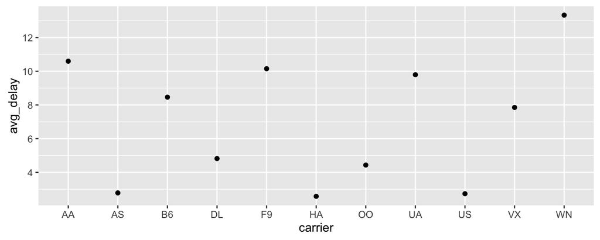

```r
library(ggplot2)
flights %>%
  group_by(carrier) %>%
  summarize(avg_delay = mean(dep_delay, na.rm = TRUE)) %>%
  arrange(desc(avg_delay)) %>%
  qplot(x = carrier, y = avg_delay, data = ., geom = "point")
```

## The `.`

When forming a chain, the `%>%` operator will default to putting the output of one function into the first argument of the next. You can change where this argument "lands" by using `.`

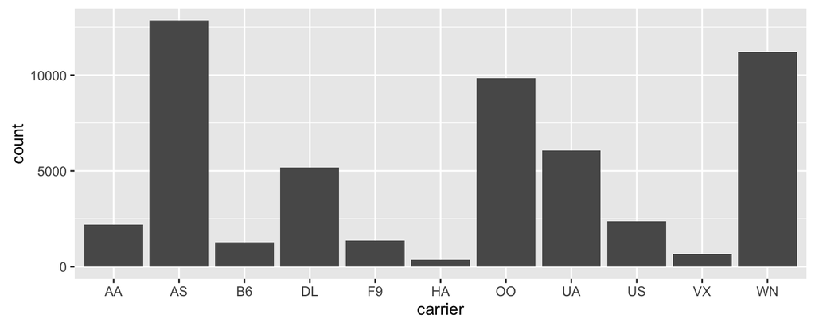

```r
flights %>%
  filter(origin == "PDX") %>%
  qplot(x = carrier, data = ., geom = "bar")
```